# Fisherian interval primary genes graph

#load library

```r
library(dplyr)
library(tidyr)

#clear the environment
rm(list=ls())

load("/Users/anqiwang/Documents/GitHub/Ozone-and-Lung-Functions/primary_genes/Exp_data_primary_CpG.RData")

load("/Users/anqiwang/Documents/GitHub/Ozone-and-Lung-Functions/Data/w0true.Rdata")
```

# Example 1: cg03610073 of TLR2. Effect size= -0.018702

```r
mn <- which(colnames(final_primary_CpG)=="cg03610073")   #provide the column number for the CpG site
#all possible randomizations
n <- 2^17

#create a data frame that contains the CpG site of interest
final1<-
  final_primary_CpG %>%
  select(c(1:4),mn) %>%
  rename(Y_obs = cg03610073)

#data wrangling
#ozone, 1=O3
final2 <-
  final1%>%
  filter(exp==1) %>%
  rename(Yi_wiO3 = Y_obs)%>%
  select(3,4,5)

#clean air, -1=CA
final3 <-
  final1 %>%
  filter(exp==-1)%>%
  rename(Yi_wiCA = Y_obs)%>%
  select(3,4,5)


#full join table final4 with final2 or final 3, respectively
final4 <-
  full_join(final1, final2, by = c("id2" = "id2", "exp" = "exp")) %>%
  select(1,2,3,4,6,5)

final4<-
  full_join(final4, final3, by = c("id2" = "id2", "exp" = "exp")) %>%
  select(1,2,3,4,5,7,6)
```

#constuct formulas to calculate p value for a list of a values and find the ones with p value larger than 0.025(due to two sided test(absolute value)) to construct fischer confidence interval

#for lower boundry. This CpG site has a negative effect size –>calculating p value should use <= #should have no absolute value when calculating p value

```r
a=200
vectora_low = as.matrix(seq(-0.043, 0, length.out = a)) #if changing the number of a values here length.out=# of a values

x<-list()

for(i in 1:a) { # of a value in the loop
  #substitute the NA value in Yi_1 with the correponding value in Yi_0 but "a" more
final4 <-
  full_join(final1, final2, by = c("id2" = "id2", "exp" = "exp")) %>%
  select(1,2,3,4,6,5)

final4<-
  full_join(final4, final3, by = c("id2" = "id2", "exp" = "exp")) %>%
  select(1,2,3,4,5,7,6)

#substitute the NA value in Yi_1 with the correponding value in Yi_0 but a more
final4$Yi_wiO3[is.na(final4$Yi_wiO3)] <- final4$Yi_wiCA[final4$exp==-1]+vectora_low[i,1]
final4$Yi_wiCA[is.na(final4$Yi_wiCA)] <- final4$Yi_wiO3[final4$exp==1]-vectora_low[i,1]
x[[i]]<-final4
print(i)
#when negative effect size, clean air (control) has larger values than the treatment O3
}
```

```r
library(parallel)

list_p_low <- matrix(nrow=a, ncol=1)  # nrow= number of a values

# Function for processing a single `i`
compute_p_value <- function(i) {
  id <- x[[i]]$"id2"
  W_obs <- x[[i]]$"exp"
  Yi_CA <- x[[i]]$"Yi_wiCA"
  Yi_O3 <- x[[i]]$"Yi_wiO3"
  Y_obs <- x[[i]]$"Y_obs"

  # Compute statistics for all j in one step
  stat <- apply(w0.true, 1, function(w) { #1 represents applying each row in W0.true
    t.test(Yi_CA[w == -1], Yi_O3[w == 1], paired=TRUE)$statistic
  })

  # Observed statistics (no absolute value)
  stat_obs <- t.test(Y_obs[W_obs == -1], Y_obs[W_obs == 1], paired=TRUE)$statistic

  # Compute p-value
  p_value <- 1*sum(stat<=stat_obs)/n

  return(p_value)
}

# Parallel execution
cl <- makeCluster(detectCores() - 1)  # Use all but one core
clusterExport(cl, c("x", "w0.true", "n"))  # Added "n" to the export list
library(pbapply)
list_p_low[, 1] <- pbsapply(1:a, compute_p_value, cl = cl) # each run compute_p_value(i) for different i values.
```

```
  |                                                  | 0 % ~calculating
  |++                                                | 3 % ~12m 31s
  |++++                                              | 7 % ~11m 45s
  |++++++                                            | 10% ~11m 08s
  |+++++++                                           | 14% ~10m 55s
  |+++++++++                                         | 17% ~10m 23s
  |+++++++++++                                       | 21% ~09m 55s
  |+++++++++++++                                     | 24% ~09m 23s
  |++++++++++++++                                    | 28% ~08m 52s
  |++++++++++++++++                                  | 31% ~08m 23s
  |++++++++++++++++++                                | 34% ~07m 53s
  |+++++++++++++++++++                               | 38% ~07m 30s
  |+++++++++++++++++++++                             | 41% ~07m 08s
  |+++++++++++++++++++++++                           | 45% ~06m 44s
  |+++++++++++++++++++++++++                         | 48% ~06m 30s
  |++++++++++++++++++++++++++                        | 52% ~06m 05s
  |++++++++++++++++++++++++++++                      | 55% ~05m 39s
  |++++++++++++++++++++++++++++++                    | 59% ~05m 13s
  |++++++++++++++++++++++++++++++++                  | 62% ~04m 46s
  |+++++++++++++++++++++++++++++++++                 | 66% ~04m 19s
  |+++++++++++++++++++++++++++++++++++               | 69% ~03m 52s
  |+++++++++++++++++++++++++++++++++++++             | 72% ~03m 25s
  |++++++++++++++++++++++++++++++++++++++            | 76% ~02m 59s
  |++++++++++++++++++++++++++++++++++++++++          | 79% ~02m 34s
  |++++++++++++++++++++++++++++++++++++++++++        | 83% ~02m 08s
  |++++++++++++++++++++++++++++++++++++++++++++      | 86% ~01m 44s
  |+++++++++++++++++++++++++++++++++++++++++++++     | 90% ~01m 19s
  |+++++++++++++++++++++++++++++++++++++++++++++++   | 93% ~53s
  |+++++++++++++++++++++++++++++++++++++++++++++++++ | 97% ~27s
  |++++++++++++++++++++++++++++++++++++++++++++++++++| 100% elapsed=12m 47s
```

```r
stopCluster(cl)
```

#for upper boundry. This CpG site has a negative effect size –>calculating p value should use >=

```r
a=200
vectora = as.matrix(seq(-0.04, 0, length.out = a)) #if changing the number of a values here length.out=# of a values

x<-list()

for(i in 1:a) { # of a value in the loop
  #substitute the NA value in Yi_1 with the correponding value in Yi_0 but "a" more
final4 <-
  full_join(final1, final2, by = c("id2" = "id2", "exp" = "exp")) %>%
  select(1,2,3,4,6,5)

final4<-
  full_join(final4, final3, by = c("id2" = "id2", "exp" = "exp")) %>%
  select(1,2,3,4,5,7,6)

#substitute the NA value in Yi_1 with the correponding value in Yi_0 but a more
final4$Yi_wiO3[is.na(final4$Yi_wiO3)] <- final4$Yi_wiCA[final4$exp==-1]+vectora[i,1]
final4$Yi_wiCA[is.na(final4$Yi_wiCA)] <- final4$Yi_wiO3[final4$exp==1]-vectora[i,1]
x[[i]]<-final4
}
```

```r
list_p<- matrix(nrow=a, ncol=1)  # nrow= number of a values

# Function for processing a single `i`
compute_p_value <- function(i) {
  id <- x[[i]]$"id2"
  W_obs <- x[[i]]$"exp"
  Yi_CA <- x[[i]]$"Yi_wiCA"
  Yi_O3 <- x[[i]]$"Yi_wiO3"
  Y_obs <- x[[i]]$"Y_obs"

  # Compute statistics for all j in one step
  stat <- apply(w0.true, 1, function(w) { #1 represents applying each row in W0.true
    t.test(Yi_CA[w == -1], Yi_O3[w == 1], paired=TRUE)$statistic
  })

  # Observed statistics (no absolute value)
  stat_obs <- t.test(Y_obs[W_obs == -1], Y_obs[W_obs == 1], paired=TRUE)$statistic

  # Compute p-value
  p_value <- 1*sum(stat>=stat_obs)/n

  return(p_value)
}

# Parallel execution
cl <- makeCluster(detectCores() - 1)  # Use all but one core
clusterExport(cl, c("x", "w0.true", "n"))  # Added "n" to the export list
library(pbapply)
list_p[, 1] <- pbsapply(1:a, compute_p_value, cl = cl) # each run compute_p_value(i) for different i values.
```

```
  |                                                  | 0 % ~calculating
  |++                                                | 3 % ~12m 46s
  |++++                                              | 7 % ~13m 27s
  |++++++                                            | 10% ~12m 28s
  |+++++++                                           | 14% ~11m 41s
  |+++++++++                                         | 17% ~11m 18s
  |+++++++++++                                       | 21% ~10m 40s
  |+++++++++++++                                     | 24% ~10m 01s
  |++++++++++++++                                    | 28% ~09m 28s
  |++++++++++++++++                                  | 31% ~09m 03s
  |++++++++++++++++++                                | 34% ~08m 35s
  |+++++++++++++++++++                               | 38% ~08m 06s
  |+++++++++++++++++++++                             | 41% ~07m 53s
  |+++++++++++++++++++++++                           | 45% ~07m 27s
  |+++++++++++++++++++++++++                         | 48% ~07m 05s
  |++++++++++++++++++++++++++                        | 52% ~06m 38s
  |++++++++++++++++++++++++++++                      | 55% ~06m 21s
  |++++++++++++++++++++++++++++++                    | 59% ~05m 59s
  |++++++++++++++++++++++++++++++++                  | 62% ~05m 29s
  |+++++++++++++++++++++++++++++++++                 | 66% ~04m 56s
  |+++++++++++++++++++++++++++++++++++               | 69% ~04m 25s
  |+++++++++++++++++++++++++++++++++++++             | 72% ~03m 54s
  |++++++++++++++++++++++++++++++++++++++            | 76% ~03m 25s
  |++++++++++++++++++++++++++++++++++++++++          | 79% ~02m 55s
  |++++++++++++++++++++++++++++++++++++++++++        | 83% ~02m 25s
  |++++++++++++++++++++++++++++++++++++++++++++      | 86% ~01m 56s
  |+++++++++++++++++++++++++++++++++++++++++++++     | 90% ~01m 26s
  |+++++++++++++++++++++++++++++++++++++++++++++++   | 93% ~57s
  |+++++++++++++++++++++++++++++++++++++++++++++++++ | 97% ~28s
  |++++++++++++++++++++++++++++++++++++++++++++++++++| 100% elapsed=13m 30s
```

```r
stopCluster(cl)
```

# visualization

# graphing of lower boundry (df1)

[figure not shown]

```r
#lower boundry
library(ggplot2)

# Assuming vectora_low and list_p_low are vectors
df1 <- data.frame(vectora_low, list_p_low = list_p_low[,1])  # Convert to dataframe

ggplot(df, aes(x = vectora_low, y = list_p_low)) +
  geom_point(color = "blue", size = 2, alpha = 0.6) +  # Scatter plot
  geom_hline(yintercept = 0.025, linetype = "dashed", color = "red", size = 1) +  # Horizontal line
  labs(
    title = "P-values across different hypothetical constant treatment effect (a) for cg03610073",
    x = "Hypothetical constant treatment effect (a)",
    y = "p-value"
  ) +
  theme_classic()   # Use a clean theme
```

```r
NA
```

#graphing of upper boundry (df2)

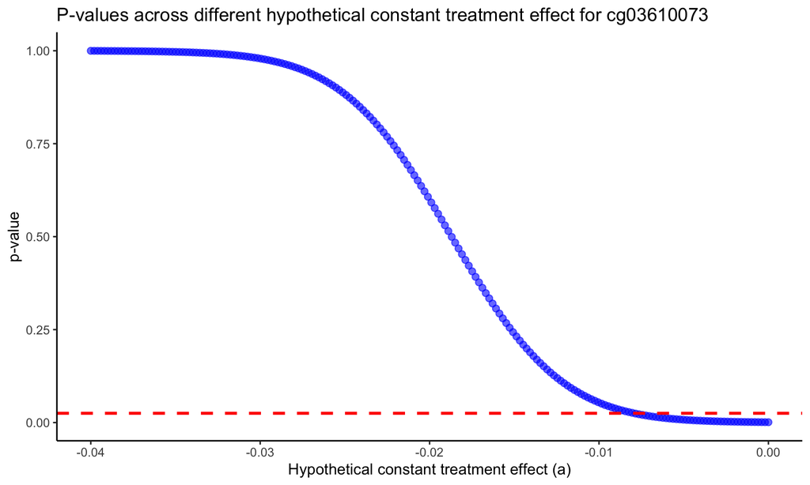

```r
#upper boundry
library(ggplot2)

# Assuming vectora_low and list_p_low are vectors
df2 <- data.frame(vectora, list_p = list_p[,1])  # Convert to dataframe

ggplot(df2, aes(x = vectora, y = list_p)) +
  geom_point(color = "blue", size = 2, alpha = 0.6) +  # Scatter plot
  geom_hline(yintercept = 0.025, linetype = "dashed", color = "red", size = 1) +  # Horizontal line
  labs(
    title = "P-values across different hypothetical constant treatment effect for cg03610073",
    x = "Hypothetical constant treatment effect (a)",
    y = "p-value"
  ) +
  theme_classic()   # Use a clean theme
```

## fisherian interval is [-0.02953789,-0.0079]

# Section 2: cg18652319 of TLR2. effect size=0.002462

```r
load("/Users/anqiwang/Documents/GitHub/Ozone-and-Lung-Functions/primary_genes/Exp_data_primary_CpG.RData")

load("/Users/anqiwang/Documents/GitHub/Ozone-and-Lung-Functions/Data/w0true.Rdata")

mn <- which(colnames(final_primary_CpG)=="cg18652319")   #provide the column number for the CpG site

#all possible randomizations
n <- 2^17

#create a data frame that contains the CpG site of interest
final1<-
  final_primary_CpG %>%
  select(c(1:4),mn) %>%
  rename(Y_obs = cg18652319)

#data wrangling
#ozone, 1=O3
final2 <-
  final1%>%
  filter(exp==1) %>%
  rename(Yi_wiO3 = Y_obs)%>%
  select(3,4,5)

#clean air, -1=CA
final3 <-
  final1 %>%
  filter(exp==-1)%>%
  rename(Yi_wiCA = Y_obs)%>%
  select(3,4,5)


#full join table final4 with final2 or final 3, respectively
final4 <-
  full_join(final1, final2, by = c("id2" = "id2", "exp" = "exp")) %>%
  select(1,2,3,4,6,5)

final4<-
  full_join(final4, final3, by = c("id2" = "id2", "exp" = "exp")) %>%
  select(1,2,3,4,5,7,6)
```

#for lower boundry. This CpG site has a positive effect size –>calculating p value should use >= #should have no absolute value when calculating p value

```r
a=200
vectora_low = as.matrix(seq(0, 0.005, length.out = a)) #if changing the number of a values here length.out=# of a values

x<-list()

for(i in 1:a) { # of a value in the loop
  #substitute the NA value in Yi_1 with the correponding value in Yi_0 but "a" more
final4 <-
  full_join(final1, final2, by = c("id2" = "id2", "exp" = "exp")) %>%
  select(1,2,3,4,6,5)

final4<-
  full_join(final4, final3, by = c("id2" = "id2", "exp" = "exp")) %>%
  select(1,2,3,4,5,7,6)

#substitute the NA value in Yi_1 with the correponding value in Yi_0 but a more
final4$Yi_wiO3[is.na(final4$Yi_wiO3)] <- final4$Yi_wiCA[final4$exp==-1]+vectora_low[i,1]
final4$Yi_wiCA[is.na(final4$Yi_wiCA)] <- final4$Yi_wiO3[final4$exp==1]-vectora_low[i,1]
x[[i]]<-final4
}
```

```r
#create a matrix with all p-values corresponding to each value a

library(parallel)

list_p_low <- matrix(nrow=a, ncol=1)  # nrow= number of a values

# Function for processing a single `i`
compute_p_value <- function(i) {
  id <- x[[i]]$"id2"
  W_obs <- x[[i]]$"exp"
  Yi_CA <- x[[i]]$"Yi_wiCA"
  Yi_O3 <- x[[i]]$"Yi_wiO3"
  Y_obs <- x[[i]]$"Y_obs"

  # Compute statistics for all j in one step
  stat <- apply(w0.true, 1, function(w) { #1 represents applying each row in W0.true
    t.test(Yi_O3[w == 1], Yi_CA[w == -1],paired=TRUE)$statistic
  })

  # Observed statistics (no absolute value)
  stat_obs <- t.test(Y_obs[W_obs == 1], Y_obs[W_obs == -1],paired=TRUE)$statistic

  # Compute p-value
  p_value <- 1*sum(stat>=stat_obs)/n

  return(p_value)
}

# Parallel execution
cl <- makeCluster(detectCores() - 1)  # Use all but one core
clusterExport(cl, c("x", "w0.true", "n"))  # Added "n" to the export list
library(pbapply)
list_p_low[, 1] <- pbsapply(1:a, compute_p_value, cl = cl) # each run compute_p_value(i) for different i values.
```

```
  |                                                  | 0 % ~calculating
  |++                                                | 3 % ~23m 23s
  |++++                                              | 7 % ~23m 27s
  |++++++                                            | 10% ~22m 18s
  |+++++++                                           | 14% ~26m 35s
  |+++++++++                                         | 17% ~33m 23s
  |+++++++++++                                       | 21% ~30m 36s
  |+++++++++++++                                     | 24% ~27m 50s
  |++++++++++++++                                    | 28% ~25m 24s
  |++++++++++++++++                                  | 31% ~24m 06s
  |++++++++++++++++++                                | 34% ~22m 40s
  |+++++++++++++++++++                               | 38% ~21m 14s
  |+++++++++++++++++++++                             | 41% ~19m 36s
  |+++++++++++++++++++++++                           | 45% ~18m 03s
  |+++++++++++++++++++++++++                         | 48% ~16m 32s
  |++++++++++++++++++++++++++                        | 52% ~15m 06s
  |++++++++++++++++++++++++++++                      | 55% ~13m 43s
  |++++++++++++++++++++++++++++++                    | 59% ~12m 27s
  |++++++++++++++++++++++++++++++++                  | 62% ~11m 14s
  |+++++++++++++++++++++++++++++++++                 | 66% ~10m 05s
  |+++++++++++++++++++++++++++++++++++               | 69% ~08m 57s
  |+++++++++++++++++++++++++++++++++++++             | 72% ~07m 51s
  |++++++++++++++++++++++++++++++++++++++            | 76% ~06m 47s
  |++++++++++++++++++++++++++++++++++++++++          | 79% ~05m 45s
  |++++++++++++++++++++++++++++++++++++++++++        | 83% ~04m 45s
  |++++++++++++++++++++++++++++++++++++++++++++      | 86% ~03m 46s
  |+++++++++++++++++++++++++++++++++++++++++++++     | 90% ~02m 48s
  |+++++++++++++++++++++++++++++++++++++++++++++++   | 93% ~01m 51s
  |+++++++++++++++++++++++++++++++++++++++++++++++++ | 97% ~55s
  |++++++++++++++++++++++++++++++++++++++++++++++++++| 100% elapsed=26m 23s
```

```r
stopCluster(cl)
```

#for upper boundry. This CpG site has a positive effect size –>calculating p value should use <=

```r
a=200
vectora = as.matrix(seq(0, 0.007368421, length.out = a)) #if changing the number of a values here length.out=# of a values

x<-list()

for(i in 1:a) { # of a value in the loop
  #substitute the NA value in Yi_1 with the correponding value in Yi_0 but "a" more
final4 <-
  full_join(final1, final2, by = c("id2" = "id2", "exp" = "exp")) %>%
  select(1,2,3,4,6,5)

final4<-
  full_join(final4, final3, by = c("id2" = "id2", "exp" = "exp")) %>%
  select(1,2,3,4,5,7,6)

#substitute the NA value in Yi_1 with the correponding value in Yi_0 but a more
final4$Yi_wiO3[is.na(final4$Yi_wiO3)] <- final4$Yi_wiCA[final4$exp==-1]+vectora[i,1]
final4$Yi_wiCA[is.na(final4$Yi_wiCA)] <- final4$Yi_wiO3[final4$exp==1]-vectora[i,1]
x[[i]]<-final4
}
```

```r
#create a matrix with all p-values corresponding to each value a
list_p<- matrix(nrow=a, ncol=1)  # nrow= number of a values

# Function for processing a single `i`
compute_p_value <- function(i) {
  id <- x[[i]]$"id2"
  W_obs <- x[[i]]$"exp"
  Yi_CA <- x[[i]]$"Yi_wiCA"
  Yi_O3 <- x[[i]]$"Yi_wiO3"
  Y_obs <- x[[i]]$"Y_obs"

  # Compute statistics for all j in one step
  stat <- apply(w0.true, 1, function(w) { #1 represents applying each row in W0.true
    t.test(Yi_O3[w == 1], Yi_CA[w == -1], paired=TRUE)$statistic
  })

  # Observed statistics (no absolute value)
  stat_obs <- t.test(Y_obs[W_obs == 1], Y_obs[W_obs == -1], paired=TRUE)$statistic

  # Compute p-value
  p_value <- 1*sum(stat<=stat_obs)/n

  return(p_value)
}

# Parallel execution
cl <- makeCluster(detectCores() - 1)  # Use all but one core
clusterExport(cl, c("x", "w0.true", "n"))  # Added "n" to the export list
library(pbapply)
list_p[, 1] <- pbsapply(1:a, compute_p_value, cl = cl) # each run compute_p_value(i) for different i values.
```

```
  |                                                  | 0 % ~calculating
  |++                                                | 3 % ~26m 57s
  |++++                                              | 7 % ~25m 26s
  |++++++                                            | 10% ~24m 36s
  |+++++++                                           | 14% ~23m 20s
  |+++++++++                                         | 17% ~22m 32s
  |+++++++++++                                       | 21% ~21m 54s
  |+++++++++++++                                     | 24% ~22m 34s
  |++++++++++++++                                    | 28% ~22m 05s
  |++++++++++++++++                                  | 31% ~21m 16s
  |++++++++++++++++++                                | 34% ~20m 22s
  |+++++++++++++++++++                               | 38% ~19m 24s
  |+++++++++++++++++++++                             | 41% ~19m 09s
  |+++++++++++++++++++++++                           | 45% ~18m 22s
  |+++++++++++++++++++++++++                         | 48% ~18m 24s
  |++++++++++++++++++++++++++                        | 52% ~17m 49s
  |++++++++++++++++++++++++++++                      | 55% ~16m 29s
  |++++++++++++++++++++++++++++++                    | 59% ~15m 11s
  |++++++++++++++++++++++++++++++++                  | 62% ~13m 44s
  |+++++++++++++++++++++++++++++++++                 | 66% ~12m 17s
  |+++++++++++++++++++++++++++++++++++               | 69% ~10m 56s
  |+++++++++++++++++++++++++++++++++++++             | 72% ~09m 34s
  |++++++++++++++++++++++++++++++++++++++            | 76% ~08m 16s
  |++++++++++++++++++++++++++++++++++++++++          | 79% ~06m 60s
  |++++++++++++++++++++++++++++++++++++++++++        | 83% ~05m 45s
  |++++++++++++++++++++++++++++++++++++++++++++      | 86% ~04m 33s
  |+++++++++++++++++++++++++++++++++++++++++++++     | 90% ~03m 23s
  |+++++++++++++++++++++++++++++++++++++++++++++++   | 93% ~02m 14s
  |+++++++++++++++++++++++++++++++++++++++++++++++++ | 97% ~01m 06s
  |++++++++++++++++++++++++++++++++++++++++++++++++++| 100% elapsed=31m 31s
```

```r
stopCluster(cl)
```

# visualization

# graphing of lower boundry (df3)

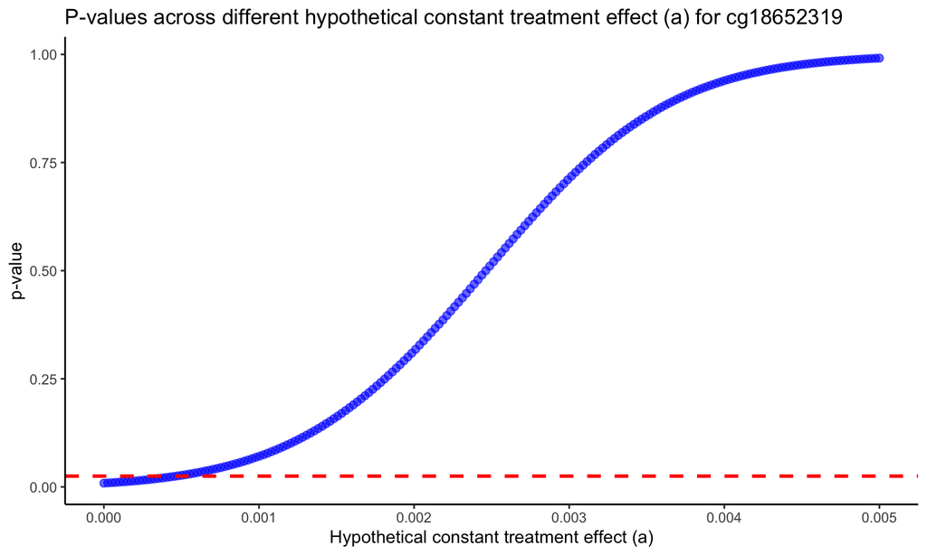

```r
#lower boundry
library(ggplot2)

# Assuming vectora_low and list_p_low are vectors
df3 <- data.frame(vectora_low, list_p_low = list_p_low[,1])  # Convert to dataframe

ggplot(df3, aes(x = vectora_low, y = list_p_low)) +
  geom_point(color = "blue", size = 2, alpha = 0.6) +  # Scatter plot
  geom_hline(yintercept = 0.025, linetype = "dashed", color = "red", size = 1) +  # Horizontal line
  labs(
    title = "P-values across different hypothetical constant treatment effect (a) for cg18652319",
    x = "Hypothetical constant treatment effect (a)",
    y = "p-value"
  ) +
  theme_classic()   # Use a clean theme
```

```r
NA
```

#graphing of upper boundry cg18652319 (df4)

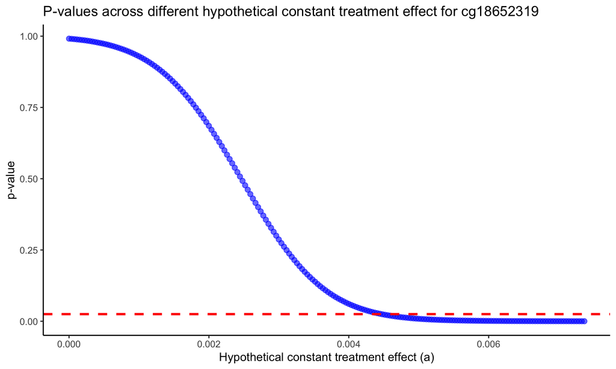

# Confidence interval: [0.0004094737, 0.004467368]

#Section 3: cg03995486 of NOS2. effect sizes=0.008566

```r
mn <- which(colnames(final_primary_CpG)=="cg03995486")   #provide the column number for the CpG site

#all possible randomizations
n <- 2^17

#create a data frame that contains the CpG site of interest
final1<-
  final_primary_CpG %>%
  select(c(1:4),mn) %>%
  rename(Y_obs = cg03995486)

#data wrangling
#ozone, 1=O3
final2 <-
  final1%>%
  filter(exp==1) %>%
  rename(Yi_wiO3 = Y_obs)%>%
  select(3,4,5)

#clean air, -1=CA
final3 <-
  final1 %>%
  filter(exp==-1)%>%
  rename(Yi_wiCA = Y_obs)%>%
  select(3,4,5)


#full join table final4 with final2 or final 3, respectively
final4 <-
  full_join(final1, final2, by = c("id2" = "id2", "exp" = "exp")) %>%
  select(1,2,3,4,6,5)

final4<-
  full_join(final4, final3, by = c("id2" = "id2", "exp" = "exp")) %>%
  select(1,2,3,4,5,7,6)
```

#for lower boundry. This CpG site has a positive effect size –>calculating p value should use >= #should have no absolute value when calculating p value

```r
a=200
vectora_low = as.matrix(seq(-0.01, 0.025, length.out = a)) #if changing the number of a values here length.out=# of a values

x<-list()

for(i in 1:a) { # of a value in the loop
  #substitute the NA value in Yi_1 with the correponding value in Yi_0 but "a" more
final4 <-
  full_join(final1, final2, by = c("id2" = "id2", "exp" = "exp")) %>%
  select(1,2,3,4,6,5)

final4<-
  full_join(final4, final3, by = c("id2" = "id2", "exp" = "exp")) %>%
  select(1,2,3,4,5,7,6)

#substitute the NA value in Yi_1 with the correponding value in Yi_0 but a more
final4$Yi_wiO3[is.na(final4$Yi_wiO3)] <- final4$Yi_wiCA[final4$exp==-1]+vectora_low[i,1]
final4$Yi_wiCA[is.na(final4$Yi_wiCA)] <- final4$Yi_wiO3[final4$exp==1]-vectora_low[i,1]
x[[i]]<-final4
}
```

```r
#create a matrix with all p-values corresponding to each value a

library(parallel)

list_p_low <- matrix(nrow=a, ncol=1)  # nrow= number of a values

# Function for processing a single `i`
compute_p_value <- function(i) {
  id <- x[[i]]$"id2"
  W_obs <- x[[i]]$"exp"
  Yi_CA <- x[[i]]$"Yi_wiCA"
  Yi_O3 <- x[[i]]$"Yi_wiO3"
  Y_obs <- x[[i]]$"Y_obs"

  # Compute statistics for all j in one step
  stat <- apply(w0.true, 1, function(w) { #1 represents applying each row in W0.true
    t.test(Yi_O3[w == 1], Yi_CA[w == -1],paired=TRUE)$statistic
  })

  # Observed statistics (no absolute value)
  stat_obs <- t.test(Y_obs[W_obs == 1], Y_obs[W_obs == -1],paired=TRUE)$statistic

  # Compute p-value
  p_value <- 1*sum(stat>=stat_obs)/n

  return(p_value)
}

# Parallel execution
cl <- makeCluster(detectCores() - 1)  # Use all but one core
clusterExport(cl, c("x", "w0.true", "n"))  # Added "n" to the export list
library(pbapply)
list_p_low[, 1] <- pbsapply(1:a, compute_p_value, cl = cl) # each run compute_p_value(i) for different i values.
```

```
  |                                                  | 0 % ~calculating
  |++                                                | 3 % ~27m 21s
```

# for upper boundry. This CpG site has a positive effect size –>calculating p value should use <=

```r
a=200
vectora = as.matrix(seq(0, 0.028254847, length.out = a)) #if changing the number of a values here length.out=# of a values

x<-list()

for(i in 1:a) { # of a value in the loop
  #substitute the NA value in Yi_1 with the correponding value in Yi_0 but "a" more
final4 <-
  full_join(final1, final2, by = c("id2" = "id2", "exp" = "exp")) %>%
  select(1,2,3,4,6,5)

final4<-
  full_join(final4, final3, by = c("id2" = "id2", "exp" = "exp")) %>%
  select(1,2,3,4,5,7,6)

#substitute the NA value in Yi_1 with the correponding value in Yi_0 but a more
final4$Yi_wiO3[is.na(final4$Yi_wiO3)] <- final4$Yi_wiCA[final4$exp==-1]+vectora[i,1]
final4$Yi_wiCA[is.na(final4$Yi_wiCA)] <- final4$Yi_wiO3[final4$exp==1]-vectora[i,1]
x[[i]]<-final4
}
```

```r
#create a matrix with all p-values corresponding to each value a
library(parallel)
list_p<- matrix(nrow=a, ncol=1)  # nrow= number of a values

# Function for processing a single `i`
compute_p_value <- function(i) {
  id <- x[[i]]$"id2"
  W_obs <- x[[i]]$"exp"
  Yi_CA <- x[[i]]$"Yi_wiCA"
  Yi_O3 <- x[[i]]$"Yi_wiO3"
  Y_obs <- x[[i]]$"Y_obs"

  # Compute statistics for all j in one step
  stat <- apply(w0.true, 1, function(w) { #1 represents applying each row in W0.true
    t.test(Yi_O3[w == 1], Yi_CA[w == -1], paired=TRUE)$statistic
  })

  # Observed statistics (no absolute value)
  stat_obs <- t.test(Y_obs[W_obs == 1], Y_obs[W_obs == -1], paired=TRUE)$statistic

  # Compute p-value
  p_value <- 1*sum(stat<=stat_obs)/n

  return(p_value)
}

# Parallel execution
cl <- makeCluster(detectCores() - 1)  # Use all but one core
clusterExport(cl, c("x", "w0.true", "n"))  # Added "n" to the export list
library(pbapply)
list_p[, 1] <- pbsapply(1:a, compute_p_value, cl = cl) # each run compute_p_value(i) for different i values.
```

```
  |                                                  | 0 % ~calculating
  |++                                                | 3 % ~13m 02s
  |++++                                              | 7 % ~13m 03s
  |++++++                                            | 10% ~13m 05s
```

# visualization

#graphing of lower boundry (df5)

```r
#lower boundry
library(ggplot2)
pdf("/Users/anqiwang/Desktop/ozone_paper_images/cg03995486_fish_int_low.pdf", width = 8, height = 6, pointsize = 12, family = "Times")  # Specify the file name

# Assuming vectora_low and list_p_low are vectors
df5 <- data.frame(vectora_low, list_p_low = list_p_low[,1])  # Convert to dataframe

ggplot(df5, aes(x = vectora_low, y = list_p_low)) +
  geom_point(color = "blue", size = 2, alpha = 0.6) +  # Scatter plot
  geom_hline(yintercept = 0.025, linetype = "dashed", color = "red", size = 1) +  # Horizontal line
  labs(
    title = "P-values across different hypothetical constant treatment effect for cg03995486",
    x = "Hypothetical constant treatment effect (a)",
    y = "p-value"
  ) +
  theme_classic()   # Use a clean theme

dev.off()
```

#graphing of upper boundry (df6)

```r
#upper boundry
pdf("/Users/anqiwang/Desktop/ozone_paper_images/cg03995486_fish_int_up.pdf", width = 8, height = 6, pointsize = 12, family = "Times")
library(ggplot2)

# Assuming vectora_low and list_p_low are vectors
df6 <- data.frame(vectora, list_p = list_p[,1])  # Convert to dataframe

ggplot(df6, aes(x = vectora, y = list_p)) +
  geom_point(color = "blue", size = 2, alpha = 0.6) +  # Scatter plot
  geom_hline(yintercept = 0.025, linetype = "dashed", color = "red", size = 1) +  # Horizontal line
  labs(
    title = "P-values across different hypothetical constant treatment effect for cg03995486",
    x = "Hypothetical constant treatment effect (a)",
    y = "p-value"
  ) +
  theme_classic()   # Use a clean theme
dev.off()
```

# 95% confidence interval is (0.001568421,0.01555263)

# Section 4: cg01133890 of MUC5B, effect size = -0.011

```r
mn <- which(colnames(final_primary_CpG)=="cg01133890")   #provide the column number for the CpG site

#all possible randomizations
n <- 2^17

#create a data frame that contains the CpG site of interest
final1<-
  final_primary_CpG %>%
  select(c(1:4),mn) %>%
  rename(Y_obs = cg01133890)
```

```
Note: Using an external vector in selections is ambiguous.
ℹ Use `all_of(mn)` instead of `mn` to silence this message.
ℹ See <https://tidyselect.r-lib.org/reference/faq-external-vector.html>.
```

```r
#data wrangling
#ozone, 1=O3
final2 <-
  final1%>%
  filter(exp==1) %>%
  rename(Yi_wiO3 = Y_obs)%>%
  select(3,4,5)

#clean air, -1=CA
final3 <-
  final1 %>%
  filter(exp==-1)%>%
  rename(Yi_wiCA = Y_obs)%>%
  select(3,4,5)


#full join table final4 with final2 or final 3, respectively
final4 <-
  full_join(final1, final2, by = c("id2" = "id2", "exp" = "exp")) %>%
  select(1,2,3,4,6,5)

final4<-
  full_join(final4, final3, by = c("id2" = "id2", "exp" = "exp")) %>%
  select(1,2,3,4,5,7,6)
```

#for lower boundry. This CpG site has a negative effect size –>calculating p value should use <= #should have no absolute value when calculating p value

```r
a=200
vectora_low = as.matrix(seq(-0.03, 0, length.out = a)) #if changing the number of a values here length.out=# of a values

x<-list()

for(i in 1:a) { # of a value in the loop
  #substitute the NA value in Yi_1 with the correponding value in Yi_0 but "a" more
final4 <-
  full_join(final1, final2, by = c("id2" = "id2", "exp" = "exp")) %>%
  select(1,2,3,4,6,5)

final4<-
  full_join(final4, final3, by = c("id2" = "id2", "exp" = "exp")) %>%
  select(1,2,3,4,5,7,6)

#substitute the NA value in Yi_1 with the correponding value in Yi_0 but a more
final4$Yi_wiO3[is.na(final4$Yi_wiO3)] <- final4$Yi_wiCA[final4$exp==-1]+vectora_low[i,1]
final4$Yi_wiCA[is.na(final4$Yi_wiCA)] <- final4$Yi_wiO3[final4$exp==1]-vectora_low[i,1]
x[[i]]<-final4
}
```

```r
library(parallel)

list_p_low <- matrix(nrow=a, ncol=1)  # nrow= number of a values

# Function for processing a single `i`
compute_p_value <- function(i) {
  id <- x[[i]]$"id2"
  W_obs <- x[[i]]$"exp"
  Yi_CA <- x[[i]]$"Yi_wiCA"
  Yi_O3 <- x[[i]]$"Yi_wiO3"
  Y_obs <- x[[i]]$"Y_obs"

  # Compute statistics for all j in one step
  stat <- apply(w0.true, 1, function(w) { #1 represents applying each row in W0.true
    t.test(Yi_CA[w == -1], Yi_O3[w == 1], paired=TRUE)$statistic
  })

  # Observed statistics (no absolute value)
  stat_obs <- t.test(Y_obs[W_obs == -1], Y_obs[W_obs == 1], paired=TRUE)$statistic

  # Compute p-value
  p_value <- 1*sum(stat<=stat_obs)/n

  return(p_value)
}

# Parallel execution
cl <- makeCluster(detectCores() - 1)  # Use all but one core
clusterExport(cl, c("x", "w0.true", "n"))  # Added "n" to the export list
library(pbapply)
list_p_low[, 1] <- pbsapply(1:a, compute_p_value, cl = cl) # each run compute_p_value(i) for different i values.
stopCluster(cl)
```

#for upper boundry. This CpG site has a negative effect size –>calculating p value should use >=

```r
a=2
vectora = as.matrix(seq(0, 0.02, length.out = a)) #if changing the number of a values here length.out=# of a values

x<-list()

for(i in 1:a) { # of a value in the loop
  #substitute the NA value in Yi_1 with the correponding value in Yi_0 but "a" more
final4 <-
  full_join(final1, final2, by = c("id2" = "id2", "exp" = "exp")) %>%
  select(1,2,3,4,6,5)

final4<-
  full_join(final4, final3, by = c("id2" = "id2", "exp" = "exp")) %>%
  select(1,2,3,4,5,7,6)

#substitute the NA value in Yi_1 with the correponding value in Yi_0 but a more
final4$Yi_wiO3[is.na(final4$Yi_wiO3)] <- final4$Yi_wiCA[final4$exp==-1]+vectora[i,1]
final4$Yi_wiCA[is.na(final4$Yi_wiCA)] <- final4$Yi_wiO3[final4$exp==1]-vectora[i,1]
x[[i]]<-final4
}
```

```r
list_p<- matrix(nrow=a, ncol=1)  # nrow= number of a values

# Function for processing a single `i`
compute_p_value <- function(i) {
  id <- x[[i]]$"id2"
  W_obs <- x[[i]]$"exp"
  Yi_CA <- x[[i]]$"Yi_wiCA"
  Yi_O3 <- x[[i]]$"Yi_wiO3"
  Y_obs <- x[[i]]$"Y_obs"

  # Compute statistics for all j in one step
  stat <- apply(w0.true, 1, function(w) { #1 represents applying each row in W0.true
    t.test(Yi_CA[w == -1], Yi_O3[w == 1], paired=TRUE)$statistic
  })

  # Observed statistics (no absolute value)
  stat_obs <- t.test(Y_obs[W_obs == -1], Y_obs[W_obs == 1], paired=TRUE)$statistic

  # Compute p-value
  p_value <- 1*sum(stat>=stat_obs)/n

  return(p_value)
}

# Parallel execution
cl <- makeCluster(detectCores() - 1)  # Use all but one core
clusterExport(cl, c("x", "w0.true", "n"))  # Added "n" to the export list
library(pbapply)
list_p[, 1] <- pbsapply(1:a, compute_p_value, cl = cl) # each run compute_p_value(i) for different i values.
stopCluster(cl)
```

# visualization

# graphing of lower boundry (df7)

```r
#lower boundry
library(ggplot2)
pdf("/Users/anqiwang/Desktop/ozone_paper_images/cg01133890_fish_int_low.pdf", width = 8, height = 6, pointsize = 12, family = "Times")  # Specify the file name

# Assuming vectora_low and list_p_low are vectors
df7 <- data.frame(vectora_low, list_p_low = list_p_low[,1])  # Convert to dataframe

ggplot(df7, aes(x = vectora_low, y = list_p_low)) +
  geom_point(color = "blue", size = 2, alpha = 0.6) +  # Scatter plot
  geom_hline(yintercept = 0.025, linetype = "dashed", color = "red", size = 1) +  # Horizontal line
  labs(
    title = "P-values across different hypothetical constant treatment effect for cg01133890",
    x = "Hypothetical constant treatment effect (a)",
    y = "p-value"
  ) +
  theme_classic()   # Use a clean theme

dev.off()
```

#graphing of upper boundry (df8)

```r
#upper boundry
pdf("/Users/anqiwang/Desktop/ozone_paper_images/cg01133890_fish_int_up.pdf", width = 8, height = 6, pointsize = 12, family = "Times")
library(ggplot2)

# Assuming vectora_low and list_p_low are vectors
df8 <- data.frame(vectora, list_p = list_p[,1])  # Convert to dataframe

ggplot(df8, aes(x = vectora, y = list_p)) +
  geom_point(color = "blue", size = 2, alpha = 0.6) +  # Scatter plot
  geom_hline(yintercept = 0.025, linetype = "dashed", color = "red", size = 1) +  # Horizontal line
  labs(
    title = "P-values across different hypothetical constant treatment effect for cg01133890",
    x = "Hypothetical constant treatment effect (a)",
    y = "p-value"
  ) +
  theme_classic()   # Use a clean theme
dev.off()
```

# confidence interval is (-0.02094737, -0.002131579)

#Section 5: cg05106269 of ICAM1. effective size = 0.009854

```r
mn <- which(colnames(final_primary_CpG)=="cg05106269")   #provide the column number for the CpG site

#all possible randomizations
n <- 2^17

#create a data frame that contains the CpG site of interest
final1<-
  final_primary_CpG %>%
  select(c(1:4),mn) %>%
  rename(Y_obs = cg05106269)

#data wrangling
#ozone, 1=O3
final2 <-
  final1%>%
  filter(exp==1) %>%
  rename(Yi_wiO3 = Y_obs)%>%
  select(3,4,5)

#clean air, -1=CA
final3 <-
  final1 %>%
  filter(exp==-1)%>%
  rename(Yi_wiCA = Y_obs)%>%
  select(3,4,5)


#full join table final4 with final2 or final 3, respectively
final4 <-
  full_join(final1, final2, by = c("id2" = "id2", "exp" = "exp")) %>%
  select(1,2,3,4,6,5)

final4<-
  full_join(final4, final3, by = c("id2" = "id2", "exp" = "exp")) %>%
  select(1,2,3,4,5,7,6)
```

#for lower boundry. This CpG site has a positive effect size –>calculating p value should use >= #should have no absolute value when calculating p value

```r
a=20
vectora_low = as.matrix(seq(-0.03, 0.047368421, length.out = a)) #if changing the number of a values here length.out=# of a values

x<-list()

for(i in 1:a) { # of a value in the loop
  #substitute the NA value in Yi_1 with the correponding value in Yi_0 but "a" more
final4 <-
  full_join(final1, final2, by = c("id2" = "id2", "exp" = "exp")) %>%
  select(1,2,3,4,6,5)

final4<-
  full_join(final4, final3, by = c("id2" = "id2", "exp" = "exp")) %>%
  select(1,2,3,4,5,7,6)

#substitute the NA value in Yi_1 with the correponding value in Yi_0 but a more
final4$Yi_wiO3[is.na(final4$Yi_wiO3)] <- final4$Yi_wiCA[final4$exp==-1]+vectora_low[i,1]
final4$Yi_wiCA[is.na(final4$Yi_wiCA)] <- final4$Yi_wiO3[final4$exp==1]-vectora_low[i,1]
x[[i]]<-final4
}
```

```r
#create a matrix with all p-values corresponding to each value a

library(parallel)

list_p_low <- matrix(nrow=a, ncol=1)  # nrow= number of a values

# Function for processing a single `i`
compute_p_value <- function(i) {
  id <- x[[i]]$"id2"
  W_obs <- x[[i]]$"exp"
  Yi_CA <- x[[i]]$"Yi_wiCA"
  Yi_O3 <- x[[i]]$"Yi_wiO3"
  Y_obs <- x[[i]]$"Y_obs"

  # Compute statistics for all j in one step
  stat <- apply(w0.true, 1, function(w) { #1 represents applying each row in W0.true
    t.test(Yi_O3[w == 1], Yi_CA[w == -1],paired=TRUE)$statistic
  })

  # Observed statistics (no absolute value)
  stat_obs <- t.test(Y_obs[W_obs == 1], Y_obs[W_obs == -1],paired=TRUE)$statistic

  # Compute p-value
  p_value <- 1*sum(stat>=stat_obs)/n

  return(p_value)
}

# Parallel execution
cl <- makeCluster(detectCores() - 1)  # Use all but one core
clusterExport(cl, c("x", "w0.true", "n"))  # Added "n" to the export list
library(pbapply)
list_p_low[, 1] <- pbsapply(1:a, compute_p_value, cl = cl) # each run compute_p_value(i) for different i values.
stopCluster(cl)
```

# for upper boundry. This CpG site has a positive effect size –>calculating p value should use <=

```r
a=200
vectora = as.matrix(seq(-0.002631579, 0.047368421, length.out = a)) #if changing the number of a values here length.out=# of a values

x<-list()

for(i in 1:a) { # of a value in the loop
  #substitute the NA value in Yi_1 with the correponding value in Yi_0 but "a" more
final4 <-
  full_join(final1, final2, by = c("id2" = "id2", "exp" = "exp")) %>%
  select(1,2,3,4,6,5)

final4<-
  full_join(final4, final3, by = c("id2" = "id2", "exp" = "exp")) %>%
  select(1,2,3,4,5,7,6)

#substitute the NA value in Yi_1 with the correponding value in Yi_0 but a more
final4$Yi_wiO3[is.na(final4$Yi_wiO3)] <- final4$Yi_wiCA[final4$exp==-1]+vectora[i,1]
final4$Yi_wiCA[is.na(final4$Yi_wiCA)] <- final4$Yi_wiO3[final4$exp==1]-vectora[i,1]
x[[i]]<-final4
}
```

```r
#create a matrix with all p-values corresponding to each value a
library(parallel)
list_p<- matrix(nrow=a, ncol=1)  # nrow= number of a values

# Function for processing a single `i`
compute_p_value <- function(i) {
  id <- x[[i]]$"id2"
  W_obs <- x[[i]]$"exp"
  Yi_CA <- x[[i]]$"Yi_wiCA"
  Yi_O3 <- x[[i]]$"Yi_wiO3"
  Y_obs <- x[[i]]$"Y_obs"

  # Compute statistics for all j in one step
  stat <- apply(w0.true, 1, function(w) { #1 represents applying each row in W0.true
    t.test(Yi_O3[w == 1], Yi_CA[w == -1], paired=TRUE)$statistic
  })

  # Observed statistics (no absolute value)
  stat_obs <- t.test(Y_obs[W_obs == 1], Y_obs[W_obs == -1], paired=TRUE)$statistic

  # Compute p-value
  p_value <- 1*sum(stat<=stat_obs)/n

  return(p_value)
}

# Parallel execution
cl <- makeCluster(detectCores() - 1)  # Use all but one core
clusterExport(cl, c("x", "w0.true", "n"))  # Added "n" to the export list
library(pbapply)
list_p[, 1] <- pbsapply(1:a, compute_p_value, cl = cl) # each run compute_p_value(i) for different i values.
```

```
  |                                                  | 0 % ~calculating
  |++                                                | 3 % ~14m 06s
  |++++                                              | 7 % ~12m 39s
  |++++++                                            | 10% ~11m 41s
  |+++++++                                           | 14% ~11m 07s
  |+++++++++                                         | 17% ~10m 44s
  |+++++++++++                                       | 21% ~10m 16s
  |+++++++++++++                                     | 24% ~09m 49s
  |++++++++++++++                                    | 28% ~09m 48s
  |++++++++++++++++                                  | 31% ~09m 17s
  |++++++++++++++++++                                | 34% ~08m 44s
  |+++++++++++++++++++                               | 38% ~08m 14s
  |+++++++++++++++++++++                             | 41% ~07m 43s
  |+++++++++++++++++++++++                           | 45% ~07m 36s
  |+++++++++++++++++++++++++                         | 48% ~07m 04s
  |++++++++++++++++++++++++++                        | 52% ~06m 40s
  |++++++++++++++++++++++++++++                      | 55% ~06m 10s
  |++++++++++++++++++++++++++++++                    | 59% ~05m 40s
  |++++++++++++++++++++++++++++++++                  | 62% ~05m 14s
  |+++++++++++++++++++++++++++++++++                 | 66% ~04m 44s
  |+++++++++++++++++++++++++++++++++++               | 69% ~04m 14s
  |+++++++++++++++++++++++++++++++++++++             | 72% ~03m 44s
  |++++++++++++++++++++++++++++++++++++++            | 76% ~03m 15s
  |++++++++++++++++++++++++++++++++++++++++          | 79% ~02m 46s
  |++++++++++++++++++++++++++++++++++++++++++        | 83% ~02m 20s
  |++++++++++++++++++++++++++++++++++++++++++++      | 86% ~01m 52s
  |+++++++++++++++++++++++++++++++++++++++++++++     | 90% ~01m 24s
  |+++++++++++++++++++++++++++++++++++++++++++++++   | 93% ~56s
  |+++++++++++++++++++++++++++++++++++++++++++++++++ | 97% ~28s
  |++++++++++++++++++++++++++++++++++++++++++++++++++| 100% elapsed=13m 17s
```

```r
stopCluster(cl)
```

# visualization

# graphing of lower boundry (df9)

```r
#lower boundry
library(ggplot2)
pdf("/Users/anqiwang/Desktop/ozone_paper_images/cg05106269_fish_int_low.pdf", width = 8, height = 6, pointsize = 12, family = "Times")  # Specify the file name

# Assuming vectora_low and list_p_low are vectors
df9 <- data.frame(vectora_low, list_p_low = list_p_low[,1])  # Convert to dataframe

ggplot(df9, aes(x = vectora_low, y = list_p_low)) +
  geom_point(color = "blue", size = 2, alpha = 0.6) +  # Scatter plot
  geom_hline(yintercept = 0.025, linetype = "dashed", color = "red", size = 1) +  # Horizontal line
  labs(
    title = "P-values across different hypothetical constant treatment effect for cg05106269",
    x = "Hypothetical constant treatment effect (a)",
    y = "p-value"
  ) +
  theme_classic()   # Use a clean theme

dev.off()
```

#graphing of upper boundry (df10)

```r
#upper boundry
pdf("/Users/anqiwang/Desktop/cg05106269_fish_int_up.pdf", width = 8, height = 6, pointsize = 12, family = "Times")
library(ggplot2)

# Assuming vectora_low and list_p_low are vectors
df10 <- data.frame(vectora, list_p = list_p[,1])  # Convert to dataframe

ggplot(df10, aes(x = vectora, y = list_p)) +
  geom_point(color = "blue", size = 2, alpha = 0.6) +  # Scatter plot
  geom_hline(yintercept = 0.025, linetype = "dashed", color = "red", size = 1) +  # Horizontal line
  labs(
    title = "P-values across different hypothetical constant treatment effect for cg05106269",
    x = "Hypothetical constant treatment effect (a)",
    y = "p-value"
  ) +
  theme_classic()   # Use a clean theme
dev.off()
```

# confidence interval is [0.0008894737,0.01916632]

#Section 6: cg00087425 of IL6. effect size = 0.0233. positive effect size

```r
mn <- which(colnames(final_primary_CpG)=="cg00087425")   #provide the column number for the CpG site

#all possible randomizations
n <- 2^17

#create a data frame that contains the CpG site of interest
final1<-
  final_primary_CpG %>%
  select(c(1:4),mn) %>%
  rename(Y_obs = cg00087425)

#data wrangling
#ozone, 1=O3
final2 <-
  final1%>%
  filter(exp==1) %>%
  rename(Yi_wiO3 = Y_obs)%>%
  select(3,4,5)

#clean air, -1=CA
final3 <-
  final1 %>%
  filter(exp==-1)%>%
  rename(Yi_wiCA = Y_obs)%>%
  select(3,4,5)


#full join table final4 with final2 or final 3, respectively
final4 <-
  full_join(final1, final2, by = c("id2" = "id2", "exp" = "exp")) %>%
  select(1,2,3,4,6,5)

final4<-
  full_join(final4, final3, by = c("id2" = "id2", "exp" = "exp")) %>%
  select(1,2,3,4,5,7,6)
```

#for lower boundry. This CpG site has a positive effect size –>calculating p value should use >= #should have no absolute value when calculating p value

```r
a=200
vectora_low = as.matrix(seq(-0.036426593, 0.078947368, length.out = a)) #if changing the number of a values here length.out=# of a values

x<-list()

for(i in 1:a) { # of a value in the loop
  #substitute the NA value in Yi_1 with the correponding value in Yi_0 but "a" more
final4 <-
  full_join(final1, final2, by = c("id2" = "id2", "exp" = "exp")) %>%
  select(1,2,3,4,6,5)

final4<-
  full_join(final4, final3, by = c("id2" = "id2", "exp" = "exp")) %>%
  select(1,2,3,4,5,7,6)

#substitute the NA value in Yi_1 with the correponding value in Yi_0 but a more
final4$Yi_wiO3[is.na(final4$Yi_wiO3)] <- final4$Yi_wiCA[final4$exp==-1]+vectora_low[i,1]
final4$Yi_wiCA[is.na(final4$Yi_wiCA)] <- final4$Yi_wiO3[final4$exp==1]-vectora_low[i,1]
x[[i]]<-final4
}
```

```r
#create a matrix with all p-values corresponding to each value a

library(parallel)

list_p_low <- matrix(nrow=a, ncol=1)  # nrow= number of a values

# Function for processing a single `i`
compute_p_value <- function(i) {
  id <- x[[i]]$"id2"
  W_obs <- x[[i]]$"exp"
  Yi_CA <- x[[i]]$"Yi_wiCA"
  Yi_O3 <- x[[i]]$"Yi_wiO3"
  Y_obs <- x[[i]]$"Y_obs"

  # Compute statistics for all j in one step
  stat <- apply(w0.true, 1, function(w) { #1 represents applying each row in W0.true
    t.test(Yi_O3[w == 1], Yi_CA[w == -1],paired=TRUE)$statistic
  })

  # Observed statistics (no absolute value)
  stat_obs <- t.test(Y_obs[W_obs == 1], Y_obs[W_obs == -1],paired=TRUE)$statistic

  # Compute p-value
  p_value <- 1*sum(stat>=stat_obs)/n

  return(p_value)
}

# Parallel execution
cl <- makeCluster(detectCores() - 1)  # Use all but one core
clusterExport(cl, c("x", "w0.true", "n"))  # Added "n" to the export list
library(pbapply)
list_p_low[, 1] <- pbsapply(1:a, compute_p_value, cl = cl) # each run compute_p_value(i) for different i values.
```

```
  |                                                  | 0 % ~calculating
  |++                                                | 3 % ~17m 24s
  |++++                                              | 7 % ~23m 10s
  |++++++                                            | 10% ~19m 52s
  |+++++++                                           | 14% ~17m 02s
  |+++++++++                                         | 17% ~16m 56s
  |+++++++++++                                       | 21% ~15m 42s
  |+++++++++++++                                     | 24% ~15m 00s
  |++++++++++++++                                    | 28% ~13m 55s
  |++++++++++++++++                                  | 31% ~12m 56s
  |++++++++++++++++++                                | 34% ~11m 56s
  |+++++++++++++++++++                               | 38% ~11m 00s
  |+++++++++++++++++++++                             | 41% ~10m 09s
  |+++++++++++++++++++++++                           | 45% ~09m 19s
  |+++++++++++++++++++++++++                         | 48% ~08m 32s
  |++++++++++++++++++++++++++                        | 52% ~07m 50s
  |++++++++++++++++++++++++++++                      | 55% ~07m 11s
  |++++++++++++++++++++++++++++++                    | 59% ~06m 32s
  |++++++++++++++++++++++++++++++++                  | 62% ~05m 53s
  |+++++++++++++++++++++++++++++++++                 | 66% ~05m 18s
  |+++++++++++++++++++++++++++++++++++               | 69% ~04m 46s
  |+++++++++++++++++++++++++++++++++++++             | 72% ~04m 11s
  |++++++++++++++++++++++++++++++++++++++            | 76% ~03m 38s
  |++++++++++++++++++++++++++++++++++++++++          | 79% ~03m 06s
  |++++++++++++++++++++++++++++++++++++++++++        | 83% ~02m 34s
  |++++++++++++++++++++++++++++++++++++++++++++      | 86% ~02m 02s
  |+++++++++++++++++++++++++++++++++++++++++++++     | 90% ~01m 31s
  |+++++++++++++++++++++++++++++++++++++++++++++++   | 93% ~01m 00s
  |+++++++++++++++++++++++++++++++++++++++++++++++++ | 97% ~30s
  |++++++++++++++++++++++++++++++++++++++++++++++++++| 100% elapsed=14m 14s
```

```r
stopCluster(cl)
```

# for upper boundry. This CpG site has a positive effect size –>calculating p value should use <=

```r
a=200
vectora = as.matrix(seq(-0.03, 0.079473684, length.out = a)) #if changing the number of a values here length.out=# of a values

x<-list()

for(i in 1:a) { # of a value in the loop
  #substitute the NA value in Yi_1 with the correponding value in Yi_0 but "a" more
final4 <-
  full_join(final1, final2, by = c("id2" = "id2", "exp" = "exp")) %>%
  select(1,2,3,4,6,5)

final4<-
  full_join(final4, final3, by = c("id2" = "id2", "exp" = "exp")) %>%
  select(1,2,3,4,5,7,6)

#substitute the NA value in Yi_1 with the correponding value in Yi_0 but a more
final4$Yi_wiO3[is.na(final4$Yi_wiO3)] <- final4$Yi_wiCA[final4$exp==-1]+vectora[i,1]
final4$Yi_wiCA[is.na(final4$Yi_wiCA)] <- final4$Yi_wiO3[final4$exp==1]-vectora[i,1]
x[[i]]<-final4
}
```

```r
#create a matrix with all p-values corresponding to each value a
list_p<- matrix(nrow=a, ncol=1)  # nrow= number of a values

# Function for processing a single `i`
compute_p_value <- function(i) {
  id <- x[[i]]$"id2"
  W_obs <- x[[i]]$"exp"
  Yi_CA <- x[[i]]$"Yi_wiCA"
  Yi_O3 <- x[[i]]$"Yi_wiO3"
  Y_obs <- x[[i]]$"Y_obs"

  # Compute statistics for all j in one step
  stat <- apply(w0.true, 1, function(w) { #1 represents applying each row in W0.true
    t.test(Yi_O3[w == 1], Yi_CA[w == -1], paired=TRUE)$statistic
  })

  # Observed statistics (no absolute value)
  stat_obs <- t.test(Y_obs[W_obs == 1], Y_obs[W_obs == -1], paired=TRUE)$statistic

  # Compute p-value
  p_value <- 1*sum(stat<=stat_obs)/n

  return(p_value)
}

# Parallel execution
cl <- makeCluster(detectCores() - 1)  # Use all but one core
clusterExport(cl, c("x", "w0.true", "n"))  # Added "n" to the export list
library(pbapply)
list_p[, 1] <- pbsapply(1:a, compute_p_value, cl = cl) # each run compute_p_value(i) for different i values.
```

```
  |                                                  | 0 % ~calculating
  |++                                                | 3 % ~21m 49s
  |++++                                              | 7 % ~16m 17s
  |++++++                                            | 10% ~14m 13s
  |+++++++                                           | 14% ~13m 05s
  |+++++++++                                         | 17% ~12m 05s
  |+++++++++++                                       | 21% ~11m 25s
  |+++++++++++++                                     | 24% ~10m 40s
  |++++++++++++++                                    | 28% ~10m 01s
  |++++++++++++++++                                  | 31% ~09m 24s
  |++++++++++++++++++                                | 34% ~08m 49s
  |+++++++++++++++++++                               | 38% ~08m 25s
  |+++++++++++++++++++++                             | 41% ~07m 52s
  |+++++++++++++++++++++++                           | 45% ~07m 21s
  |+++++++++++++++++++++++++                         | 48% ~06m 49s
  |++++++++++++++++++++++++++                        | 52% ~06m 19s
  |++++++++++++++++++++++++++++                      | 55% ~05m 49s
  |++++++++++++++++++++++++++++++                    | 59% ~05m 20s
  |++++++++++++++++++++++++++++++++                  | 62% ~04m 51s
  |+++++++++++++++++++++++++++++++++                 | 66% ~04m 23s
  |+++++++++++++++++++++++++++++++++++               | 69% ~03m 56s
  |+++++++++++++++++++++++++++++++++++++             | 72% ~03m 29s
  |++++++++++++++++++++++++++++++++++++++            | 76% ~03m 02s
  |++++++++++++++++++++++++++++++++++++++++          | 79% ~02m 37s
  |++++++++++++++++++++++++++++++++++++++++++        | 83% ~02m 17s
  |++++++++++++++++++++++++++++++++++++++++++++      | 86% ~01m 52s
  |+++++++++++++++++++++++++++++++++++++++++++++     | 90% ~01m 24s
  |+++++++++++++++++++++++++++++++++++++++++++++++   | 93% ~56s
  |+++++++++++++++++++++++++++++++++++++++++++++++++ | 97% ~28s
  |++++++++++++++++++++++++++++++++++++++++++++++++++| 100% elapsed=13m 26s
```

```r
stopCluster(cl)
```

# visualization

# graphing of lower boundry (df11)

```r
#lower boundry
library(ggplot2)
pdf("/Users/anqiwang/Desktop/ozone_paper_images/cg00087425_fish_int_low.pdf", width = 8, height = 6, pointsize = 12, family = "Times")  # Specify the file name

# Assuming vectora_low and list_p_low are vectors
df11 <- data.frame(vectora_low, list_p_low = list_p_low[,1])  # Convert to dataframe

ggplot(df11, aes(x = vectora_low, y = list_p_low)) +
  geom_point(color = "blue", size = 2, alpha = 0.6) +  # Scatter plot
  geom_hline(yintercept = 0.025, linetype = "dashed", color = "red", size = 1) +  # Horizontal line
  labs(
    title = "P-values across different hypothetical constant treatment effect (a) for cg00087425",
    x = "Hypothetical constant treatment effect (a)",
    y = "p-value"
  ) +
  theme_classic()   # Use a clean theme

dev.off()
```

#graphing of upper boundry (df12)

```r
#upper boundry
pdf("/Users/anqiwang/Desktop/ozone_paper_images/cg00087425_fish_int_up.pdf", width = 8, height = 6, pointsize = 12, family = "Times")
library(ggplot2)

# Assuming vectora_low and list_p_low are vectors
df12 <- data.frame(vectora, list_p = list_p[,1])  # Convert to dataframe

ggplot(df12, aes(x = vectora, y = list_p)) +
  geom_point(color = "blue", size = 2, alpha = 0.6) +  # Scatter plot
  geom_hline(yintercept = 0.025, linetype = "dashed", color = "red", size = 1) +  # Horizontal line
  labs(
    title = "P-values across different hypothetical constant treatment effect for cg00087425",
    x = "Hypothetical constant treatment effect (a)",
    y = "p-value"
  ) +
  theme_classic()   # Use a clean theme
dev.off()
```

# confidence interval: [0.002226316, 0.04378947]

#Section 7: cg02680732 of MUC 5B. effect size = -0.003436

```r
#clear the environment
mn <- which(colnames(final_primary_CpG)=="cg02680732")   #provide the column number for the CpG site

#all possible randomizations
n <- 2^17

#create a data frame that contains the CpG site of interest
final1<-
  final_primary_CpG %>%
  select(c(1:4),mn) %>%
  rename(Y_obs = cg02680732)

#data wrangling
#ozone, 1=O3
final2 <-
  final1%>%
  filter(exp==1) %>%
  rename(Yi_wiO3 = Y_obs)%>%
  select(3,4,5)

#clean air, -1=CA
final3 <-
  final1 %>%
  filter(exp==-1)%>%
  rename(Yi_wiCA = Y_obs)%>%
  select(3,4,5)


#full join table final4 with final2 or final 3, respectively
final4 <-
  full_join(final1, final2, by = c("id2" = "id2", "exp" = "exp")) %>%
  select(1,2,3,4,6,5)

final4<-
  full_join(final4, final3, by = c("id2" = "id2", "exp" = "exp")) %>%
  select(1,2,3,4,5,7,6)
```

#for lower boundry. This CpG site has a negative effect size –>calculating p value should use <= #should have no absolute value when calculating p value

```r
a=200
vectora_low = as.matrix(seq(-0.01052632, 0.005, length.out = a)) #if changing the number of a values here length.out=# of a values

x<-list()

for(i in 1:a) { # of a value in the loop
  #substitute the NA value in Yi_1 with the correponding value in Yi_0 but "a" more
final4 <-
  full_join(final1, final2, by = c("id2" = "id2", "exp" = "exp")) %>%
  select(1,2,3,4,6,5)

final4<-
  full_join(final4, final3, by = c("id2" = "id2", "exp" = "exp")) %>%
  select(1,2,3,4,5,7,6)

#substitute the NA value in Yi_1 with the correponding value in Yi_0 but a more
final4$Yi_wiO3[is.na(final4$Yi_wiO3)] <- final4$Yi_wiCA[final4$exp==-1]+vectora_low[i,1]
final4$Yi_wiCA[is.na(final4$Yi_wiCA)] <- final4$Yi_wiO3[final4$exp==1]-vectora_low[i,1]
x[[i]]<-final4
}
```

```r
library(parallel)

list_p_low <- matrix(nrow=a, ncol=1)  # nrow= number of a values

# Function for processing a single `i`
compute_p_value <- function(i) {
  id <- x[[i]]$"id2"
  W_obs <- x[[i]]$"exp"
  Yi_CA <- x[[i]]$"Yi_wiCA"
  Yi_O3 <- x[[i]]$"Yi_wiO3"
  Y_obs <- x[[i]]$"Y_obs"

  # Compute statistics for all j in one step
  stat <- apply(w0.true, 1, function(w) { #1 represents applying each row in W0.true
    t.test(Yi_CA[w == -1], Yi_O3[w == 1], paired=TRUE)$statistic
  })

  # Observed statistics (no absolute value)
  stat_obs <- t.test(Y_obs[W_obs == -1], Y_obs[W_obs == 1], paired=TRUE)$statistic

  # Compute p-value
  p_value <- 1*sum(stat<=stat_obs)/n

  return(p_value)
}

# Parallel execution
cl <- makeCluster(detectCores() - 1)  # Use all but one core
clusterExport(cl, c("x", "w0.true", "n"))  # Added "n" to the export list
library(pbapply)
list_p_low[, 1] <- pbsapply(1:a, compute_p_value, cl = cl) # each run compute_p_value(i) for different i values.
```

```
  |                                                  | 0 % ~calculating
  |++                                                | 3 % ~22m 33s
  |++++                                              | 7 % ~22m 49s
  |++++++                                            | 10% ~22m 14s
  |+++++++                                           | 14% ~21m 20s
  |+++++++++                                         | 17% ~20m 12s
  |+++++++++++                                       | 21% ~19m 49s
  |+++++++++++++                                     | 24% ~18m 51s
  |++++++++++++++                                    | 28% ~18m 08s
  |++++++++++++++++                                  | 31% ~17m 02s
  |++++++++++++++++++                                | 34% ~16m 08s
  |+++++++++++++++++++                               | 38% ~15m 20s
  |+++++++++++++++++++++                             | 41% ~14m 25s
  |+++++++++++++++++++++++                           | 45% ~13m 34s
  |+++++++++++++++++++++++++                         | 48% ~12m 41s
  |++++++++++++++++++++++++++                        | 52% ~11m 50s
  |++++++++++++++++++++++++++++                      | 55% ~11m 02s
  |++++++++++++++++++++++++++++++                    | 59% ~10m 15s
  |++++++++++++++++++++++++++++++++                  | 62% ~09m 22s
  |+++++++++++++++++++++++++++++++++                 | 66% ~08m 39s
  |+++++++++++++++++++++++++++++++++++               | 69% ~07m 45s
  |+++++++++++++++++++++++++++++++++++++             | 72% ~06m 52s
  |++++++++++++++++++++++++++++++++++++++            | 76% ~05m 58s
  |++++++++++++++++++++++++++++++++++++++++          | 79% ~05m 06s
  |++++++++++++++++++++++++++++++++++++++++++        | 83% ~04m 13s
  |++++++++++++++++++++++++++++++++++++++++++++      | 86% ~03m 22s
  |+++++++++++++++++++++++++++++++++++++++++++++     | 90% ~02m 32s
  |+++++++++++++++++++++++++++++++++++++++++++++++   | 93% ~01m 41s
  |+++++++++++++++++++++++++++++++++++++++++++++++++ | 97% ~51s
  |++++++++++++++++++++++++++++++++++++++++++++++++++| 100% elapsed=24m 14s
```

```r
stopCluster(cl)
```

#for upper boundry. This CpG site has a negative effect size –>calculating p value should use >=

```r
a=200
vectora = as.matrix(seq(-0.015789474, 0.005542628, length.out = a)) #if changing the number of a values here length.out=# of a values

x<-list()

for(i in 1:a) { # of a value in the loop
  #substitute the NA value in Yi_1 with the correponding value in Yi_0 but "a" more
final4 <-
  full_join(final1, final2, by = c("id2" = "id2", "exp" = "exp")) %>%
  select(1,2,3,4,6,5)

final4<-
  full_join(final4, final3, by = c("id2" = "id2", "exp" = "exp")) %>%
  select(1,2,3,4,5,7,6)

#substitute the NA value in Yi_1 with the correponding value in Yi_0 but a more
final4$Yi_wiO3[is.na(final4$Yi_wiO3)] <- final4$Yi_wiCA[final4$exp==-1]+vectora[i,1]
final4$Yi_wiCA[is.na(final4$Yi_wiCA)] <- final4$Yi_wiO3[final4$exp==1]-vectora[i,1]
x[[i]]<-final4
}
```

```r
list_p<- matrix(nrow=a, ncol=1)  # nrow= number of a values

# Function for processing a single `i`
compute_p_value <- function(i) {
  id <- x[[i]]$"id2"
  W_obs <- x[[i]]$"exp"
  Yi_CA <- x[[i]]$"Yi_wiCA"
  Yi_O3 <- x[[i]]$"Yi_wiO3"
  Y_obs <- x[[i]]$"Y_obs"

  # Compute statistics for all j in one step
  stat <- apply(w0.true, 1, function(w) { #1 represents applying each row in W0.true
    t.test(Yi_CA[w == -1], Yi_O3[w == 1], paired=TRUE)$statistic
  })

  # Observed statistics (no absolute value)
  stat_obs <- t.test(Y_obs[W_obs == -1], Y_obs[W_obs == 1], paired=TRUE)$statistic

  # Compute p-value
  p_value <- 1*sum(stat>=stat_obs)/n

  return(p_value)
}

# Parallel execution
cl <- makeCluster(detectCores() - 1)  # Use all but one core
clusterExport(cl, c("x", "w0.true", "n"))  # Added "n" to the export list
library(pbapply)
list_p[, 1] <- pbsapply(1:a, compute_p_value, cl = cl) # each run compute_p_value(i) for different i values.
```

```
  |                                                  | 0 % ~calculating
  |++                                                | 3 % ~22m 17s
  |++++                                              | 7 % ~21m 42s
  |++++++                                            | 10% ~20m 58s
  |+++++++                                           | 14% ~19m 52s
  |+++++++++                                         | 17% ~18m 42s
  |+++++++++++                                       | 21% ~17m 41s
  |+++++++++++++                                     | 24% ~16m 48s
  |++++++++++++++                                    | 28% ~16m 06s
  |++++++++++++++++                                  | 31% ~15m 20s
  |++++++++++++++++++                                | 34% ~14m 46s
  |+++++++++++++++++++                               | 38% ~14m 13s
  |+++++++++++++++++++++                             | 41% ~13m 22s
  |+++++++++++++++++++++++                           | 45% ~12m 29s
  |+++++++++++++++++++++++++                         | 48% ~11m 38s
  |++++++++++++++++++++++++++                        | 52% ~10m 54s
  |++++++++++++++++++++++++++++                      | 55% ~10m 09s
  |++++++++++++++++++++++++++++++                    | 59% ~09m 22s
  |++++++++++++++++++++++++++++++++                  | 62% ~08m 37s
  |+++++++++++++++++++++++++++++++++                 | 66% ~07m 51s
  |+++++++++++++++++++++++++++++++++++               | 69% ~07m 03s
  |+++++++++++++++++++++++++++++++++++++             | 72% ~06m 17s
  |++++++++++++++++++++++++++++++++++++++            | 76% ~05m 29s
  |++++++++++++++++++++++++++++++++++++++++          | 79% ~04m 42s
  |++++++++++++++++++++++++++++++++++++++++++        | 83% ~03m 60s
  |++++++++++++++++++++++++++++++++++++++++++++      | 86% ~03m 12s
  |+++++++++++++++++++++++++++++++++++++++++++++     | 90% ~02m 24s
  |+++++++++++++++++++++++++++++++++++++++++++++++   | 93% ~01m 37s
  |+++++++++++++++++++++++++++++++++++++++++++++++++ | 97% ~48s
  |++++++++++++++++++++++++++++++++++++++++++++++++++| 100% elapsed=23m 24s
```

```r
stopCluster(cl)
```

# visualization

# graphing of lower boundry (df13)

```r
#lower boundry
library(ggplot2)
pdf("/Users/anqiwang/Desktop/ozone_paper_images/cg02680732_fish_int_low.pdf", width = 8, height = 6, pointsize = 12, family = "Times")  # Specify the file name

# Assuming vectora_low and list_p_low are vectors
df13 <- data.frame(vectora_low, list_p_low = list_p_low[,1])  # Convert to dataframe

ggplot(df13, aes(x = vectora_low, y = list_p_low)) +
  geom_point(color = "blue", size = 2, alpha = 0.6) +  # Scatter plot
  geom_hline(yintercept = 0.025, linetype = "dashed", color = "red", size = 1) +  # Horizontal line
  labs(
    title = "P-values across different hypothetical constant treatment effect (a) for cg02680732",
    x = "Hypothetical constant treatment effect (a)",
    y = "p-value"
  ) +
  theme_classic()   # Use a clean theme

dev.off()
```

#graphing of upper boundry (df14)

```r
#upper boundry
pdf("/Users/anqiwang/Desktop/ozone_paper_images/cg02680732_fish_int_up.pdf", width = 8, height = 6, pointsize = 12, family = "Times")
library(ggplot2)

# Assuming vectora_low and list_p_low are vectors
df14 <- data.frame(vectora, list_p = list_p[,1])  # Convert to dataframe

ggplot(df14, aes(x = vectora, y = list_p)) +
  geom_point(color = "blue", size = 2, alpha = 0.6) +  # Scatter plot
  geom_hline(yintercept = 0.025, linetype = "dashed", color = "red", size = 1) +  # Horizontal line
  labs(
    title = "P-values across different hypothetical constant treatment effect for cg02680732",
    x = "Hypothetical constant treatment effect (a)",
    y = "p-value"
  ) +
  theme_classic()   # Use a clean theme
dev.off()
```

# confidence interval: [-0.006736842, -0.0002347368]

#Section 8: cg16547110 of TLR2. effect size=0.005242

```r
#clear the environment

mn <- which(colnames(final_primary_CpG)=="cg16547110")   #provide the column number for the CpG site

#all possible randomizations
n <- 2^17

#create a data frame that contains the CpG site of interest
final1<-
  final_primary_CpG %>%
  select(c(1:4),mn) %>%
  rename(Y_obs = cg16547110)

#data wrangling
#ozone, 1=O3
final2 <-
  final1%>%
  filter(exp==1) %>%
  rename(Yi_wiO3 = Y_obs)%>%
  select(3,4,5)

#clean air, -1=CA
final3 <-
  final1 %>%
  filter(exp==-1)%>%
  rename(Yi_wiCA = Y_obs)%>%
  select(3,4,5)


#full join table final4 with final2 or final 3, respectively
final4 <-
  full_join(final1, final2, by = c("id2" = "id2", "exp" = "exp")) %>%
  select(1,2,3,4,6,5)

final4<-
  full_join(final4, final3, by = c("id2" = "id2", "exp" = "exp")) %>%
  select(1,2,3,4,5,7,6)
```

#for lower boundry. This CpG site has a positive effect size –>calculating p value should use >= #should have no absolute value when calculating p value

```r
a=10
vectora_low = as.matrix(seq(-0.005, 0.014, length.out = a)) #if changing the number of a values here length.out=# of a values

x<-list()

for(i in 1:a) { # of a value in the loop
  #substitute the NA value in Yi_1 with the correponding value in Yi_0 but "a" more
final4 <-
  full_join(final1, final2, by = c("id2" = "id2", "exp" = "exp")) %>%
  select(1,2,3,4,6,5)

final4<-
  full_join(final4, final3, by = c("id2" = "id2", "exp" = "exp")) %>%
  select(1,2,3,4,5,7,6)

#substitute the NA value in Yi_1 with the correponding value in Yi_0 but a more
final4$Yi_wiO3[is.na(final4$Yi_wiO3)] <- final4$Yi_wiCA[final4$exp==-1]+vectora_low[i,1]
final4$Yi_wiCA[is.na(final4$Yi_wiCA)] <- final4$Yi_wiO3[final4$exp==1]-vectora_low[i,1]
x[[i]]<-final4
}
```

```r
library(parallel)

list_p_low <- matrix(nrow=a, ncol=1)  # nrow= number of a values

# Function for processing a single `i`
compute_p_value <- function(i) {
  id <- x[[i]]$"id2"
  W_obs <- x[[i]]$"exp"
  Yi_CA <- x[[i]]$"Yi_wiCA"
  Yi_O3 <- x[[i]]$"Yi_wiO3"
  Y_obs <- x[[i]]$"Y_obs"

  # Compute statistics for all j in one step
  stat <- apply(w0.true, 1, function(w) { #1 represents applying each row in W0.true
    t.test(Yi_O3[w == 1], Yi_CA[w == -1],paired=TRUE)$statistic
  })

  # Observed statistics (no absolute value)
  stat_obs <- t.test(Y_obs[W_obs == 1], Y_obs[W_obs == -1],paired=TRUE)$statistic

  # Compute p-value
  p_value <- 1*sum(stat>=stat_obs)/n

  return(p_value)
}

# Parallel execution
cl <- makeCluster(detectCores() - 1)  # Use all but one core
clusterExport(cl, c("x", "w0.true", "n"))  # Added "n" to the export list
library(pbapply)
list_p_low[, 1] <- pbsapply(1:a, compute_p_value, cl = cl) # each run compute_p_value(i) for different i values.
```

```
  |                                                  | 0 % ~calculating
  |+++++++++++++++++++++++++                         | 50% ~25s
  |++++++++++++++++++++++++++++++++++++++++++++++++++| 100% elapsed=40s
```

```r
stopCluster(cl)
```

# for upper boundry. This CpG site has a positive effect size –>calculating p value should use <=

```r
a=200
vectora = as.matrix(seq(-0.006, 0.015, length.out = a)) #if changing the number of a values here length.out=# of a values

x<-list()

for(i in 1:a) { # of a value in the loop
  #substitute the NA value in Yi_1 with the correponding value in Yi_0 but "a" more
final4 <-
  full_join(final1, final2, by = c("id2" = "id2", "exp" = "exp")) %>%
  select(1,2,3,4,6,5)

final4<-
  full_join(final4, final3, by = c("id2" = "id2", "exp" = "exp")) %>%
  select(1,2,3,4,5,7,6)

#substitute the NA value in Yi_1 with the correponding value in Yi_0 but a more
final4$Yi_wiO3[is.na(final4$Yi_wiO3)] <- final4$Yi_wiCA[final4$exp==-1]+vectora[i,1]
final4$Yi_wiCA[is.na(final4$Yi_wiCA)] <- final4$Yi_wiO3[final4$exp==1]-vectora[i,1]
x[[i]]<-final4
}
```

```r
#create a matrix with all p-values corresponding to each value a
list_p<- matrix(nrow=a, ncol=1)  # nrow= number of a values

# Function for processing a single `i`
compute_p_value <- function(i) {
  id <- x[[i]]$"id2"
  W_obs <- x[[i]]$"exp"
  Yi_CA <- x[[i]]$"Yi_wiCA"
  Yi_O3 <- x[[i]]$"Yi_wiO3"
  Y_obs <- x[[i]]$"Y_obs"

  # Compute statistics for all j in one step
  stat <- apply(w0.true, 1, function(w) { #1 represents applying each row in W0.true
    t.test(Yi_O3[w == 1], Yi_CA[w == -1], paired=TRUE)$statistic
  })

  # Observed statistics (no absolute value)
  stat_obs <- t.test(Y_obs[W_obs == 1], Y_obs[W_obs == -1], paired=TRUE)$statistic

  # Compute p-value
  p_value <- 1*sum(stat<=stat_obs)/n

  return(p_value)
}

# Parallel execution
cl <- makeCluster(detectCores() - 1)  # Use all but one core
clusterExport(cl, c("x", "w0.true", "n"))  # Added "n" to the export list
library(pbapply)
list_p[, 1] <- pbsapply(1:a, compute_p_value, cl = cl) # each run compute_p_value(i) for different i values.
stopCluster(cl)
```

# visualization

# graphing of lower boundry (df15)

```r
#lower boundry
library(ggplot2)
pdf("/Users/anqiwang/Desktop/ozone_paper_images/cg16547110_fish_int_low.pdf", width = 8, height = 6, pointsize = 12, family = "Times")  # Specify the file name

# Assuming vectora_low and list_p_low are vectors
df15 <- data.frame(vectora_low, list_p_low = list_p_low[,1])  # Convert to dataframe

ggplot(df15, aes(x = vectora_low, y = list_p_low)) +
  geom_point(color = "blue", size = 2, alpha = 0.6) +  # Scatter plot
  geom_hline(yintercept = 0.025, linetype = "dashed", color = "red", size = 1) +  # Horizontal line
  labs(
    title = "P-values across different hypothetical constant treatment effect (a) for cg16547110",
    x = "Hypothetical constant treatment effect (a)",
    y = "p-value"
  ) +
  theme_classic()   # Use a clean theme

dev.off()
```

#graphing of upper boundry (df16)

```r
#upper boundry
pdf("/Users/anqiwang/Desktop/ozone_paper_images/cg16547110_fish_int_up.pdf", width = 8, height = 6, pointsize = 12, family = "Times")
library(ggplot2)

# Assuming vectora_low and list_p_low are vectors
df16 <- data.frame(vectora, list_p = list_p[,1])  # Convert to dataframe

ggplot(df16, aes(x = vectora, y = list_p)) +
  geom_point(color = "blue", size = 2, alpha = 0.6) +  # Scatter plot
  geom_hline(yintercept = 0.025, linetype = "dashed", color = "red", size = 1) +  # Horizontal line
  labs(
    title = "P-values across different hypothetical constant treatment effect for cg16547110",
    x = "Hypothetical constant treatment effect (a)",
    y = "p-value"
  ) +
  theme_classic()   # Use a clean theme
dev.off()
```

# confidence interval: [0.0001810526, 0.01021607]

#Section 9: cg10950028 of GSTM1. effect size = -0.0157

```r
mn <- which(colnames(final_primary_CpG)=="cg10950028")   #provide the column number for the CpG site

#all possible randomizations
n <- 2^17

#create a data frame that contains the CpG site of interest
final1<-
  final_primary_CpG %>%
  select(c(1:4),mn) %>%
  rename(Y_obs = cg10950028)

#data wrangling
#ozone, 1=O3
final2 <-
  final1%>%
  filter(exp==1) %>%
  rename(Yi_wiO3 = Y_obs)%>%
  select(3,4,5)

#clean air, -1=CA
final3 <-
  final1 %>%
  filter(exp==-1)%>%
  rename(Yi_wiCA = Y_obs)%>%
  select(3,4,5)


#full join table final4 with final2 or final 3, respectively
final4 <-
  full_join(final1, final2, by = c("id2" = "id2", "exp" = "exp")) %>%
  select(1,2,3,4,6,5)

final4<-
  full_join(final4, final3, by = c("id2" = "id2", "exp" = "exp")) %>%
  select(1,2,3,4,5,7,6)
```

#for lower boundry. This CpG site has a negative effect size –>calculating p value should use <= #should have no absolute value when calculating p value

```r
a=200
vectora_low = as.matrix(seq(-0.065789474, 0.018421053, length.out = a)) #if changing the number of a values here length.out=# of a values

x<-list()

for(i in 1:a) { # of a value in the loop
  #substitute the NA value in Yi_1 with the correponding value in Yi_0 but "a" more
final4 <-
  full_join(final1, final2, by = c("id2" = "id2", "exp" = "exp")) %>%
  select(1,2,3,4,6,5)

final4<-
  full_join(final4, final3, by = c("id2" = "id2", "exp" = "exp")) %>%
  select(1,2,3,4,5,7,6)

#substitute the NA value in Yi_1 with the correponding value in Yi_0 but a more
final4$Yi_wiO3[is.na(final4$Yi_wiO3)] <- final4$Yi_wiCA[final4$exp==-1]+vectora_low[i,1]
final4$Yi_wiCA[is.na(final4$Yi_wiCA)] <- final4$Yi_wiO3[final4$exp==1]-vectora_low[i,1]
x[[i]]<-final4
}
```

```r
library(parallel)

list_p_low <- matrix(nrow=a, ncol=1)  # nrow= number of a values

# Function for processing a single `i`
compute_p_value <- function(i) {
  id <- x[[i]]$"id2"
  W_obs <- x[[i]]$"exp"
  Yi_CA <- x[[i]]$"Yi_wiCA"
  Yi_O3 <- x[[i]]$"Yi_wiO3"
  Y_obs <- x[[i]]$"Y_obs"

  # Compute statistics for all j in one step
  stat <- apply(w0.true, 1, function(w) { #1 represents applying each row in W0.true
    t.test(Yi_CA[w == -1], Yi_O3[w == 1], paired=TRUE)$statistic
  })

  # Observed statistics (no absolute value)
  stat_obs <- t.test(Y_obs[W_obs == -1], Y_obs[W_obs == 1], paired=TRUE)$statistic

  # Compute p-value
  p_value <- 1*sum(stat<=stat_obs)/n

  return(p_value)
}

# Parallel execution
cl <- makeCluster(detectCores() - 1)  # Use all but one core
clusterExport(cl, c("x", "w0.true", "n"))  # Added "n" to the export list
library(pbapply)
list_p_low[, 1] <- pbsapply(1:a, compute_p_value, cl = cl) # each run compute_p_value(i) for different i values.
```

```
  |                                                  | 0 % ~calculating
  |++                                                | 3 % ~21m 14s
  |++++                                              | 7 % ~18m 41s
  |++++++                                            | 10% ~16m 39s
  |+++++++                                           | 14% ~15m 13s
  |+++++++++                                         | 17% ~14m 56s
  |+++++++++++                                       | 21% ~13m 53s
  |+++++++++++++                                     | 24% ~12m 56s
  |++++++++++++++                                    | 28% ~12m 28s
  |++++++++++++++++                                  | 31% ~11m 39s
  |++++++++++++++++++                                | 34% ~11m 00s
  |+++++++++++++++++++                               | 38% ~10m 18s
  |+++++++++++++++++++++                             | 41% ~09m 36s
  |+++++++++++++++++++++++                           | 45% ~08m 55s
  |+++++++++++++++++++++++++                         | 48% ~08m 22s
  |++++++++++++++++++++++++++                        | 52% ~07m 46s
  |++++++++++++++++++++++++++++                      | 55% ~07m 10s
  |++++++++++++++++++++++++++++++                    | 59% ~06m 37s
  |++++++++++++++++++++++++++++++++                  | 62% ~06m 04s
  |+++++++++++++++++++++++++++++++++                 | 66% ~05m 27s
  |+++++++++++++++++++++++++++++++++++               | 69% ~04m 54s
  |+++++++++++++++++++++++++++++++++++++             | 72% ~04m 26s
  |++++++++++++++++++++++++++++++++++++++            | 76% ~03m 57s
  |++++++++++++++++++++++++++++++++++++++++          | 79% ~03m 23s
  |++++++++++++++++++++++++++++++++++++++++++        | 83% ~02m 49s
  |++++++++++++++++++++++++++++++++++++++++++++      | 86% ~02m 16s
  |+++++++++++++++++++++++++++++++++++++++++++++     | 90% ~01m 42s
  |+++++++++++++++++++++++++++++++++++++++++++++++   | 93% ~01m 08s
  |+++++++++++++++++++++++++++++++++++++++++++++++++ | 97% ~34s
  |++++++++++++++++++++++++++++++++++++++++++++++++++| 100% elapsed=16m 24s
```

```r
stopCluster(cl)
```

#for upper boundry. This CpG site has a negative effect size –>calculating p value should use >=

```r
a=200
vectora = as.matrix(seq(-0.06, 0.020526316, length.out = a)) #if changing the number of a values here length.out=# of a values

x<-list()

for(i in 1:a) { # of a value in the loop
  #substitute the NA value in Yi_1 with the correponding value in Yi_0 but "a" more
final4 <-
  full_join(final1, final2, by = c("id2" = "id2", "exp" = "exp")) %>%
  select(1,2,3,4,6,5)

final4<-
  full_join(final4, final3, by = c("id2" = "id2", "exp" = "exp")) %>%
  select(1,2,3,4,5,7,6)

#substitute the NA value in Yi_1 with the correponding value in Yi_0 but a more
final4$Yi_wiO3[is.na(final4$Yi_wiO3)] <- final4$Yi_wiCA[final4$exp==-1]+vectora[i,1]
final4$Yi_wiCA[is.na(final4$Yi_wiCA)] <- final4$Yi_wiO3[final4$exp==1]-vectora[i,1]
x[[i]]<-final4
}
```

```r
list_p<- matrix(nrow=a, ncol=1)  # nrow= number of a values

# Function for processing a single `i`
compute_p_value <- function(i) {
  id <- x[[i]]$"id2"
  W_obs <- x[[i]]$"exp"
  Yi_CA <- x[[i]]$"Yi_wiCA"
  Yi_O3 <- x[[i]]$"Yi_wiO3"
  Y_obs <- x[[i]]$"Y_obs"

  # Compute statistics for all j in one step
  stat <- apply(w0.true, 1, function(w) { #1 represents applying each row in W0.true
    t.test(Yi_CA[w == -1], Yi_O3[w == 1], paired=TRUE)$statistic
  })

  # Observed statistics (no absolute value)
  stat_obs <- t.test(Y_obs[W_obs == -1], Y_obs[W_obs == 1], paired=TRUE)$statistic

  # Compute p-value
  p_value <- 1*sum(stat>=stat_obs)/n

  return(p_value)
}

# Parallel execution
cl <- makeCluster(detectCores() - 1)  # Use all but one core
clusterExport(cl, c("x", "w0.true", "n"))  # Added "n" to the export list
library(pbapply)
list_p[, 1] <- pbsapply(1:a, compute_p_value, cl = cl) # each run compute_p_value(i) for different i values.
```

```
  |                                                  | 0 % ~calculating
  |++                                                | 3 % ~12m 37s
  |++++                                              | 7 % ~13m 03s
  |++++++                                            | 10% ~12m 49s
  |+++++++                                           | 14% ~12m 26s
  |+++++++++                                         | 17% ~11m 54s
  |+++++++++++                                       | 21% ~11m 23s
  |+++++++++++++                                     | 24% ~10m 50s
  |++++++++++++++                                    | 28% ~10m 23s
  |++++++++++++++++                                  | 31% ~09m 58s
  |++++++++++++++++++                                | 34% ~09m 38s
  |+++++++++++++++++++                               | 38% ~09m 02s
  |+++++++++++++++++++++                             | 41% ~08m 34s
  |+++++++++++++++++++++++                           | 45% ~08m 03s
  |+++++++++++++++++++++++++                         | 48% ~07m 31s
  |++++++++++++++++++++++++++                        | 52% ~06m 58s
  |++++++++++++++++++++++++++++                      | 55% ~06m 27s
  |++++++++++++++++++++++++++++++                    | 59% ~05m 55s
  |++++++++++++++++++++++++++++++++                  | 62% ~05m 27s
  |+++++++++++++++++++++++++++++++++                 | 66% ~04m 56s
  |+++++++++++++++++++++++++++++++++++               | 69% ~04m 27s
  |+++++++++++++++++++++++++++++++++++++             | 72% ~03m 56s
  |++++++++++++++++++++++++++++++++++++++            | 76% ~03m 25s
  |++++++++++++++++++++++++++++++++++++++++          | 79% ~02m 56s
  |++++++++++++++++++++++++++++++++++++++++++        | 83% ~02m 26s
  |++++++++++++++++++++++++++++++++++++++++++++      | 86% ~01m 56s
  |+++++++++++++++++++++++++++++++++++++++++++++     | 90% ~01m 27s
  |+++++++++++++++++++++++++++++++++++++++++++++++   | 93% ~58s
  |+++++++++++++++++++++++++++++++++++++++++++++++++ | 97% ~29s
  |++++++++++++++++++++++++++++++++++++++++++++++++++| 100% elapsed=13m 53s
```

```r
stopCluster(cl)
```

# confidence interval [-0.03226316, 0.0002789474]

# visualization

# graphing of lower boundry (df17)

```r
#lower boundry
library(ggplot2)
pdf("/Users/anqiwang/Desktop/ozone_paper_images/cg10950028_fish_int_low.pdf", width = 8, height = 6, pointsize = 12, family = "Times")  # Specify the file name

# Assuming vectora_low and list_p_low are vectors
df17 <- data.frame(vectora_low, list_p_low = list_p_low[,1])  # Convert to dataframe

ggplot(df17, aes(x = vectora_low, y = list_p_low)) +
  geom_point(color = "blue", size = 2, alpha = 0.6) +  # Scatter plot
  geom_hline(yintercept = 0.025, linetype = "dashed", color = "red", size = 1) +  # Horizontal line
  labs(
    title = "P-values across different hypothetical constant treatment effect (a) for cg10950028",
    x = "Hypothetical constant treatment effect (a)",
    y = "p-value"
  ) +
  theme_classic()   # Use a clean theme

dev.off()
```

#graphing of upper boundry (df18)

```r
#upper boundry
pdf("/Users/anqiwang/Desktop/ozone_paper_images/cg10950028_fish_int_up.pdf", width = 8, height = 6, pointsize = 12, family = "Times")
library(ggplot2)

# Assuming vectora_low and list_p_low are vectors
df18 <- data.frame(vectora, list_p = list_p[,1])  # Convert to dataframe

ggplot(df18, aes(x = vectora, y = list_p)) +
  geom_point(color = "blue", size = 2, alpha = 0.6) +  # Scatter plot
  geom_hline(yintercept = 0.025, linetype = "dashed", color = "red", size = 1) +  # Horizontal line
  labs(
    title = "P-values across different hypothetical constant treatment effect for cg10950028",
    x = "Hypothetical constant treatment effect (a)",
    y = "p-value"
  ) +
  theme_classic()   # Use a clean theme
dev.off()
```